# IE 582 - Homework 5

Yusuf Burak Ovali

01/07/2019

The objective of the project is to using 2 different clustering algorithms (Hierarchical and K-means) by using different distance measures (manhattan and euclidean in this report). After constructing the clusters, penalized logistic regression is applied.

# Data Preparation

Musk dataset is included as data table. For both euclidean and manhattan methods, seperate matrices are created.To have better results, scaling operation is handled.

```r
musk_datapath='Desktop/Musk1.csv'

musk1_raw = as.data.table(read.csv(musk_datapath),header = TRUE)

scaled_features = as.data.table(scale(musk1_raw[,3:ncol(musk1_raw)]))
musk1 = musk1_raw
musk1[,3:ncol(musk1)] = scaled_features
euc_dist = as.matrix(dist(scaled_features,"euclidean"))
man_dist = as.matrix(dist(scaled_features,"manhattan"))
```

## K - medoids

### Euclidean Distance

To see how many cluster is needed, elbow method is applied by using “fviz_nbclust” to get total sum of squares.

```r
library(factoextra)
```

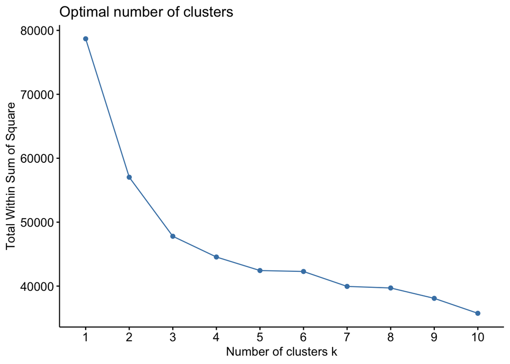

```r
fviz_nbclust(scaled_features,FUN=kmeans,method="wss",diss=euc_dist)  # elbow point = 5. now do k medoids with 5
```

The medoids are founded by using “pam” function. After finding the meoids, to calculate the distances to medoids, data table operations are made. The column names are changed and two data tables are merged.

```r
medoid_euclidean = pam(scaled_features,k=5,metric='euclidean')
euc_dist = as.data.table(euc_dist)
euc_medoids = medoid_euclidean$id.med
euc_med_distances = euc_dist[,get(as.character(as.numeric(euc_medoids[1])))]
for(i in 2:5){
euc_med_distances<-cbind(euc_med_distances,euc_dist[,get(as.character(as.numeric(euc_medoids[i])))])
}
euc_med_distances<-as.data.table(euc_med_distances)
setnames(euc_med_distances,old=colnames(euc_med_distances),new=c("Center1","Center2","Center3","Center4","Center5"))

euc_med_bag = cbind(musk1_raw[,1:2],euc_med_distances)
colnames(euc_med_bag)=c("BagClass","BagID","C1","C2","C3","C4","C5")
```

For the third step, average distances of instances to centroids are measured.

```r
euc_med_bag = as.data.table(euc_med_bag)
bag_average=aggregate(euc_med_bag,list(euc_med_bag$BagID),mean)
bag_average_woutgroup=bag_average[,-1]
colnames(bag_average_woutgroup)=c("BagClass","BagID","C1_AvgDist","C2_AvgDist","C3_AvgDist","C4_AvgDist","C5_AvgDist")
```

After finding the distances, logistic regression is applied to dataset.

To tune lambda, “penalized” package is recalled and optL1 function is deployed. After tuning the lambda, the model is fit to penald variable by using “penalized” function. That fitted model is then used for the prediction.

```r
lambda1 <- optL1(bag_average_woutgroup$BagClass, penalized = ~., data = bag_average_woutgroup[,-1],
                 fusedl = FALSE, minlambda1 = 0, maxlambda1 = 2,
                 fold = 10)

penald <- penalized(bag_average_woutgroup$BagClass, penalized = ~., data = bag_average_woutgroup[,-1],
                 lambda1 = lambda1$lambda,
                 fusedl = FALSE)
prediction<-predict(penald,penalized=bag_average_woutgroup[,-1])
prediction
```

Since the predictions are made based on the logistic regression, the probabilities are assigned to classes and confusion matrix is contructed to see accuracy.

```r
prediction[prediction>0.5]=1
prediction[prediction<=0.5]=0
prediction

confmatrix_keuc=confusionMatrix(as.factor(bag_average_woutgroup$BagClass),as.factor(prediction))
confmatrix_keuc
```

[output not shown]

For the cross validation and predictions following steps are applied. Resulting parameters are kept in to “result” data table.

```r
set.seed(133)
train_class = bag_average_woutgroup$BagClass
indices=generateCVRuns(as.factor(train_class),1,10,stratified=TRUE)
auc_crossvalid<-rep(NA,10)
traindata_wclass=cbind(train_class,bag_average_woutgroup[,-1])

for (i in 1:10) {
  Replication=indices[[1]]
  testindices=Replication[[i]]
  train=traindata_wclass[-testindices,]
  test=traindata_wclass[testindices,]
  train_classes<-train$train_class

  prediction=predict(penald,penalized=test[,2:7])

  for (k in 1:length(prediction)) {
    if (prediction[k] < 0.5) {
      prediction[k] = 0
    } else {
      prediction[k] = 1
    }
  }

  roc_obj <- roc(test$train_class, prediction)
  auc_crossvalid[i] = auc(roc_obj)
}
mean(auc_crossvalid)
result = rbind(result, data.table(Clustering_Method="K-medoid",K = "5",Best_Lambda=lambda$lambda.min, AUC=mean(auc_crossvalid),Distance="euclidean",linkage=NA ))
```

### Manhattan Distance

Same procedures are applied for manhattan distance. The codes are:

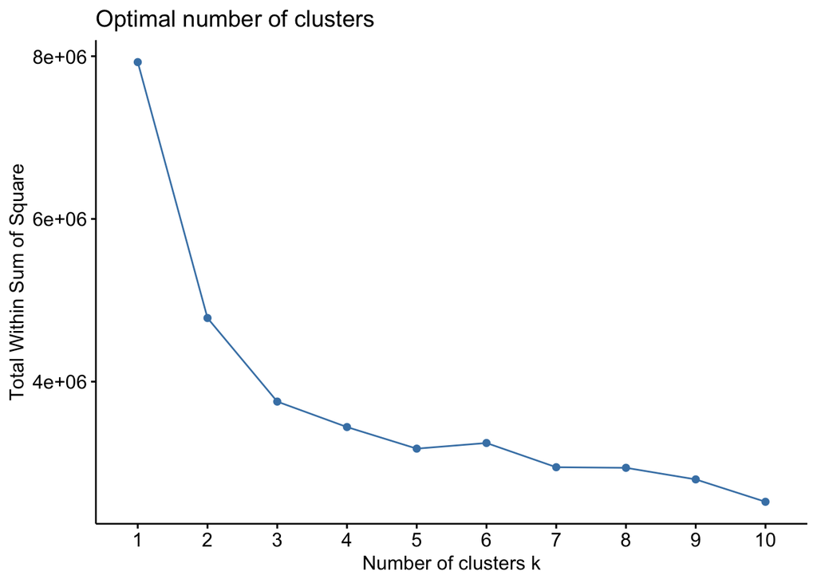

```r
fviz_nbclust(scaled_features,FUN=kmeans,method="wss",diss=man_dist)  # elbow point = 5. now do k medoids with 5
```

In that case, 3 clusters seem more logical. The following code is similar to Euclidean as follows:

```r
medoid_manhattan = pam(scaled_features,k=3,metric='manhattan')
man_dist = as.data.table(man_dist)
man_medoids = medoid_manhattan$id.med
man_med_distances = man_dist[,get(as.character(as.numeric(man_medoids[1])))]


for(i in 2:3){

  man_med_distances<-cbind(man_med_distances,man_dist[,get(as.character(as.numeric(man_medoids[i])))])
}
man_med_distances<-as.data.table(man_med_distances)
setnames(man_med_distances,old=colnames(man_med_distances),new=c("Center1","Center2","Center3"))

man_med_bag = cbind(musk1_raw[,1:2],man_med_distances)
colnames(man_med_bag)=c("BagClass","BagID","C1","C2","C3")

man_med_bag = as.data.table(man_med_bag)


bag_average_man=aggregate(man_med_bag,list(man_med_bag$BagID),mean)

bag_average_man_woutgroup=bag_average_man[,-1]
colnames(bag_average_man_woutgroup)=c("BagClass","BagID","C1_AvgDist","C2_AvgDist","C3_AvgDist")

#Logistic Regression

lambda1_man <- optL1(bag_average_man_woutgroup$BagClass, penalized = ~., data = bag_average_man_woutgroup[,-1],
                 fusedl = FALSE, minlambda1 = 0, maxlambda1 = 1,
                 fold = 10)

penald <- penalized(bag_average_man_woutgroup$BagClass, penalized = ~., data = bag_average_man_woutgroup[,-1],
                    lambda1 = lambda1_man$lambda,
                    fusedl = FALSE)
prediction_man<-predict(penald,penalized=bag_average_man_woutgroup[,-1])
prediction_man

prediction_man[prediction_man>0.5]=1
prediction_man[prediction_man<=0.5]=0
prediction_man

confmatrix_kman=confusionMatrix(as.factor(bag_average_man_woutgroup$BagClass),as.factor(prediction_man))
confmatrix_kman


set.seed(133)
train_class_man = bag_average_man_woutgroup$BagClass
indices=generateCVRuns(as.factor(train_class_man),1,10,stratified=TRUE)
auc_crossvalid_man<-rep(NA,10)
traindata_wclass_man=cbind(train_class_man,bag_average_man_woutgroup[,-1])

for (i in 1:10) {
  Replication=indices[[1]]
  testindices=Replication[[i]]
  train_man=traindata_wclass_man[-testindices,]
  test_man=traindata_wclass_man[testindices,]
  train_classes_man<-train$train_class_man
  prediction_man=predict(penald,penalized=test[,2:5])
  for (k in 1:length(prediction_man)) {
    if (prediction_man[k] < 0.5) {
      prediction_man[k] = 0
    } else {
      prediction_man[k] = 1
    }
  }
  roc_obj <- roc(test$train_class, prediction)
  auc_crossvalid[i] = auc(roc_obj)
}
mean(auc_crossvalid)
result = rbind(result, data.table(Clustering_Method="K-medoid",K = "3",Best_Lambda=lambda$lambda.min, AUC=mean(auc_crossvalid),Distance="manhattan",linkage=NA ))
```

## Hierarchical Clustering

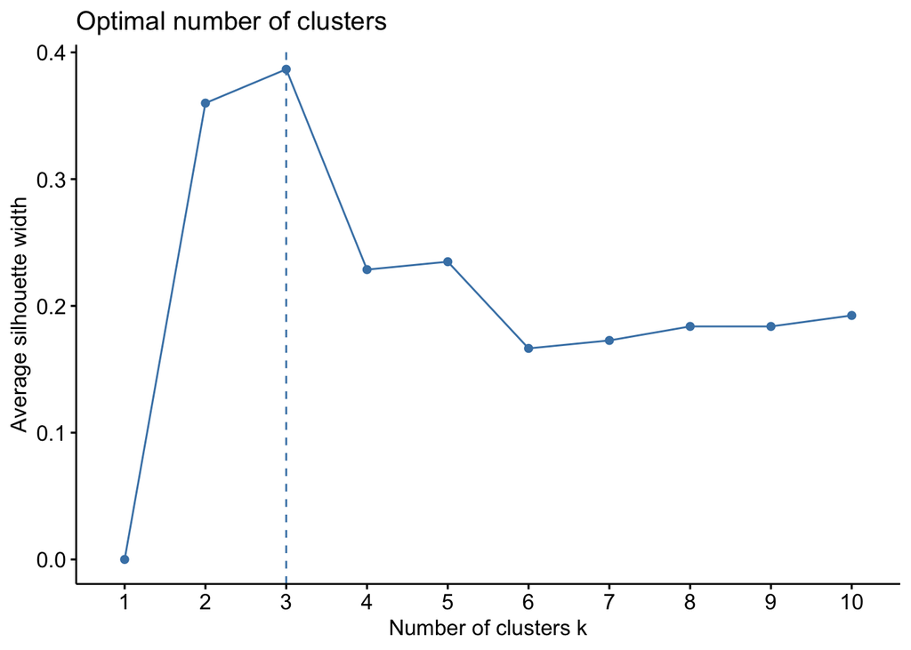

```r
fviz_nbclust(scaled_features, FUN = hcut, method = "silhouette", diss = dist(scaled_features,method = "manhattan"))
```

For this case, 3 clusters are used and the resulting dendogram is:

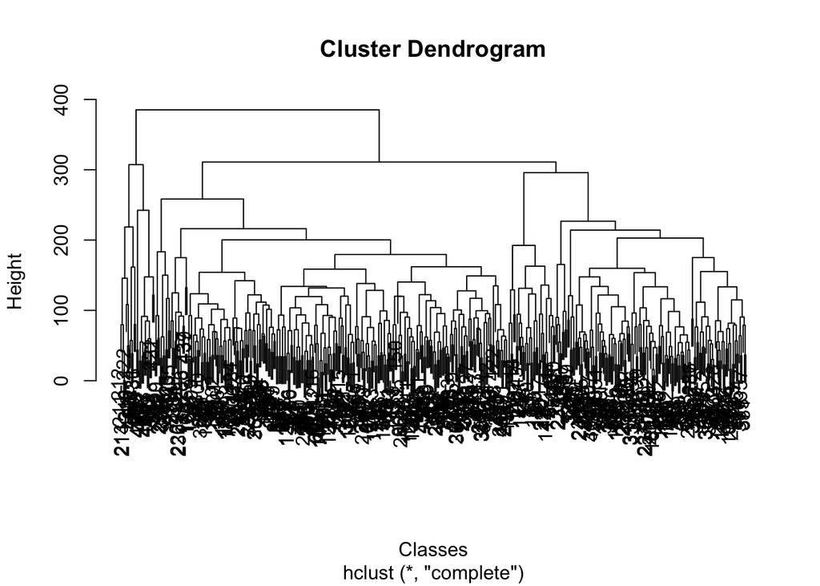

```r
hier_euc<-hclust(dist(scaled_features,"manhattan"),method="complete")
plot(hier_euc, xlab="Classes")  # bu onemlii
```

Centroids are calculated as follows:

```r
hc_cluster<-cutree (hier_euc , 3)
centroids<-data.table()
for(z in 1:3){
  temp<-subset(musk_hc)
  temp<-temp[,3:168]
  if (nrow(temp)>=2){
    cent<-pam(temp,k = 1)
    centroids<-rbind(centroids,cent$medoids)
  } else {
    centroids<-rbind(centroids,temp)
  }}
man_hc = centroids
man_hc_distances = man_dist[,get(as.character(as.numeric(man_hc[1])))]
```

After that point similar procedures are applied as k-means.

```r
for(i in 2:3){

  man_hc_distances<-cbind(man_hc_distances,man_dist[,get(as.character(as.numeric(man_hc[i])))])
}
man_hc_distances<-as.data.table(man_hc_distances)
setnames(man_hc_distances,old=colnames(man_hc_distances),new=c("Center1","Center2","Center3"))

man_hc_bag = cbind(musk1_raw[,1:2],man_hc_distances)
colnames(man_hc_bag)=c("BagClass","BagID","C1","C2","C3")

#step 3:Represent the bag as the average of its instance distances to the cluster centroids
man_hc_bag = as.data.table(man_hc_bag)


bag_average_man=aggregate(man_hc_bag,list(man_hc_bag$BagID),mean)

bag_average_man_woutgroup=bag_average_man[,-1]
colnames(bag_average_man_woutgroup)=c("BagClass","BagID","C1_AvgDist","C2_AvgDist","C3_AvgDist")

#Logistic Regression

lambda1_man <- optL1(bag_average_man_woutgroup$BagClass, penalized = ~., data = bag_average_man_woutgroup[,-1],
                     fusedl = FALSE, minlambda1 = 0, maxlambda1 = 1,
                     fold = 10)

penald <- penalized(bag_average_man_woutgroup$BagClass, penalized = ~., data = bag_average_man_woutgroup[,-1],
                    lambda1 = lambda1_man$lambda,
                    fusedl = FALSE)
prediction_man<-predict(penald,penalized=bag_average_man_woutgroup[,-1])
prediction_man

prediction_man[prediction_man>0.5]=1
prediction_man[prediction_man<=0.5]=0
prediction_man

confmatrix_hcman=confusionMatrix(as.factor(bag_average_man_woutgroup$BagClass),as.factor(prediction_man))
confmatrix_hcman


set.seed(133)
train_class_man = bag_average_man_woutgroup$BagClass
indices=generateCVRuns(as.factor(train_class_man),1,10,stratified=TRUE)
auc_crossvalid_man<-rep(NA,10)
traindata_wclass_man=cbind(train_class_man,bag_average_man_woutgroup[,-1])

for (i in 1:10) {
  Replication=indices[[1]]
  testindices=Replication[[i]]
  train_man=traindata_wclass_man[-testindices,]
  test_man=traindata_wclass_man[testindices,]
  train_classes_man<-train$train_class_man
  prediction_man=predict(penald,penalized=test[,2:5])
  for (k in 1:length(prediction_man)) {
    if (prediction_man[k] < 0.5) {
      prediction_man[k] = 0
    } else {
      prediction_man[k] = 1
    }
  }
  roc_obj <- roc(test$train_class, prediction)
  auc_crossvalid[i] = auc(roc_obj)
}
mean(auc_crossvalid)
result = rbind(result, data.table(Clustering_Method="Hierarchical Clustering",K = "3",Best_Lambda=lambda$lambda.min, AUC=mean(auc_crossvalid),Distance="manhattan",linkage=NA ))
```

The best results are recorded into result data table.

### Euclidean

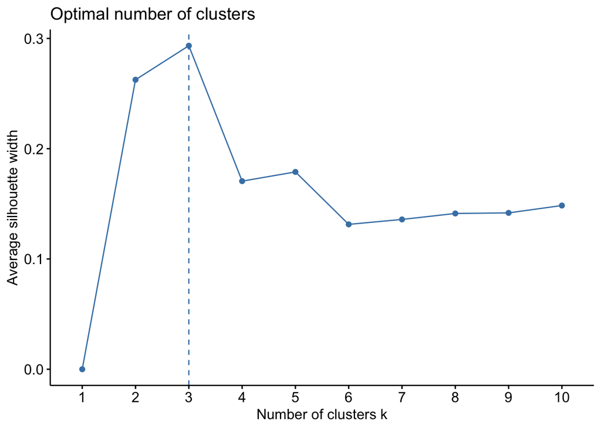

```r
fviz_nbclust(scaled_features, FUN = hcut, method = "silhouette", diss = dist(scaled_features,method = "euclidean"))
```

Again the number of clusters is 3.

The dendogram is:

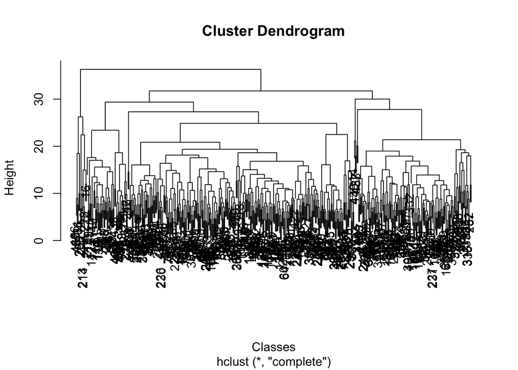

```r
hier_euc<-hclust(dist(scaled_features,"euclidean"),method="complete")
plot(hier_euc, xlab="Classes")
```

After that point, same procedures is applied as manhattan distance, the results are recorded into result data table.

```r
hc_cluster<-cutree (hier_euc , 3)

centroids<-data.table()
for(z in 1:3){
  temp<-subset(musk_hc)
  temp<-temp[,3:168]
  if (nrow(temp)>=2){
    cent<-pam(temp,k = 1)
    centroids<-rbind(centroids,cent$medoids)
  } else {
    centroids<-rbind(centroids,temp)
  }}

euc_hc = centroids
euc_hc_distances = euc_dist[,get(as.character(as.numeric(euc_hc[1])))]



for(i in 2:3){

  euc_hc_distances<-cbind(euc_hc_distances,euc_dist[,get(as.character(as.numeric(euc_hc[i])))])
}
euc_hc_distances<-as.data.table(euc_hc_distances)
setnames(euc_hc_distances,old=colnames(euc_hc_distances),new=c("Center1","Center2","Center3"))

euc_hc_bag = cbind(musk1_raw[,1:2],euc_hc_distances)
colnames(euc_hc_bag)=c("BagClass","BagID","C1","C2","C3")
euc_hc_bag = as.data.table(euc_hc_bag)


bag_average_euc=aggregate(euc_hc_bag,list(euc_hc_bag$BagID),mean)

bag_average_euc_woutgroup=bag_average_euc[,-1]
colnames(bag_average_euc_woutgroup)=c("BagClass","BagID","C1_AvgDist","C2_AvgDist","C3_AvgDist")

#Logistic Regression

lambda1_euc <- optL1(bag_average_euc_woutgroup$BagClass, penalized = ~., data = bag_average_euc_woutgroup[,-1],
                     fusedl = FALSE, minlambda1 = 0, maxlambda1 = 1,
                     fold = 10)

penald <- penalized(bag_average_euc_woutgroup$BagClass, penalized = ~., data = bag_average_euc_woutgroup[,-1],
                    lambda1 = lambda1_euc$lambda,
                    fusedl = FALSE)
prediction_euc<-predict(penald,penalized=bag_average_euc_woutgroup[,-1])
prediction_euc

prediction_euc[prediction_euc>0.5]=1
prediction_euc[prediction_euc<=0.5]=0
prediction_euc

confmatrix_hceuc=confusionMatrix(as.factor(bag_average_euc_woutgroup$BagClass),as.factor(prediction_euc))
confmatrix_hceuc


set.seed(133)
train_class_euc = bag_average_euc_woutgroup$BagClass
indices=generateCVRuns(as.factor(train_class_euc),1,10,stratified=TRUE)
auc_crossvalid_euc<-rep(NA,10)
traindata_wclass_euc=cbind(train_class_euc,bag_average_euc_woutgroup[,-1])

for (i in 1:10) {
  Replication=indices[[1]]
  testindices=Replication[[i]]
  train_euc=traindata_wclass_euc[-testindices,]
  test_euc=traindata_wclass_euc[testindices,]
  train_classes_euc<-train$train_class_euc
  prediction_euc=predict(penald,penalized=test[,2:5])
  for (k in 1:length(prediction_euc)) {
    if (prediction_euc[k] < 0.5) {
      prediction_euc[k] = 0
    } else {
      prediction_euc[k] = 1
    }
  }
  roc_obj <- roc(test$train_class, prediction)
  auc_crossvalid[i] = auc(roc_obj)
}
mean(auc_crossvalid)
result = rbind(result, data.table(Clustering_Method="Hierarchical Clustering",K = "3",Best_Lambda=lambda$lambda.min, AUC=mean(auc_crossvalid),Distance="euclidean",linkage=NA ))
```

### Results

Resulting table to compare parameters and cluster algorithms.

```r
result
```

[output not shown]

According to result table, best AUC values belongs to Hierarchical Clustering with manhattan distance.